# Practical Machine Learning Course Proyect

Miguel Rico

31 de enero de 2016

INTRODUCTION

Using devices such as Jawbone Up, Nike FuelBand, and Fitbit it is now possible to collect a large amount of data about personal activity relatively inexpensively. These type of devices are part of the quantified self movement - a group of enthusiasts who take measurements about themselves regularly to improve their health, to find patterns in their behavior, or because they are tech geeks. One thing that people regularly do is quantify how much of a particular activity they do, but they rarely quantify how well they do it. In this project, your goal will be to use data from accelerometers on the belt, forearm, arm, and dumbell of 6 participants. They were asked to perform barbell lifts correctly and incorrectly in 5 different ways. More information is available from the website here: http://groupware.les.inf.puc-rio.br/har (see the section on the Weight Lifting Exercise Dataset.

The goal of your project is to predict the manner in which they did the exercise. This is the “classe” variable in the training set. You may use any of the other variables to predict with. You should create a report describing how you built your model, how you used cross validation, what you think the expected out of sample error is, and why you made the choices you did. You will also use your prediction model to predict 20 different test cases.

Loading libraries

The next libraries were used for this project:

```r
library(caret)
library(foreign)
library('Hmisc')
library(rpart)
library(rattle)
library(randomForest)
```

Loading data

Data are uploaded from a csv file through the next code:

```r
training <- read.csv(url("https://d396qusza40orc.cloudfront.net/predmachlearn/pml-training.csv"), na.strings=c("NA",""," "))
testing<- read.csv(url("https://d396qusza40orc.cloudfront.net/predmachlearn/pml-testing.csv"), na.strings=c("NA",""," "))

dim(training);dim(training)
```

```
## [1] 19622   160
```

```
## [1] 19622   160
```

There are a lot of columns with missings values , so we have to deal with ’#DIV/0.

In order to clean our data set we have to deal with missing values and we apply the following rule: If the count of NAs in a variable is equal or greater than 70% we delete that variable.

```r
training_v3<-training[, colSums(!is.na(training)) >= nrow(training) * 0.70]
dim(training_v3)
```

```
## [1] 19622    60
```

```r
testing_v3<-testing[, colSums(!is.na(testing)) >= nrow(testing) * 0.70]
dim(testing_v3)
```

```
## [1] 20 60
```

Now we have reduced the number of variables . At the beginning there were 159 variables and now there are 60. Moreover, there are useless specific data such as timestamp,user names that should be removed from our data frame.

```r
training_v4 <- training_v3[,-(1:7)]
testing_v4<- testing_v3[,-(1:7)]
```

TRAINING AND TESTING SET

Now we have to divide the dataset in a training set an d testing set.

```r
inTrain <- createDataPartition(training_v4$classe, p=3/4)[[1]]
train <- training_v4[inTrain, ]
test <- training_v4[-inTrain, ]
```

CART TREE ALGORITHM

The first algorithm used is the cart tree.

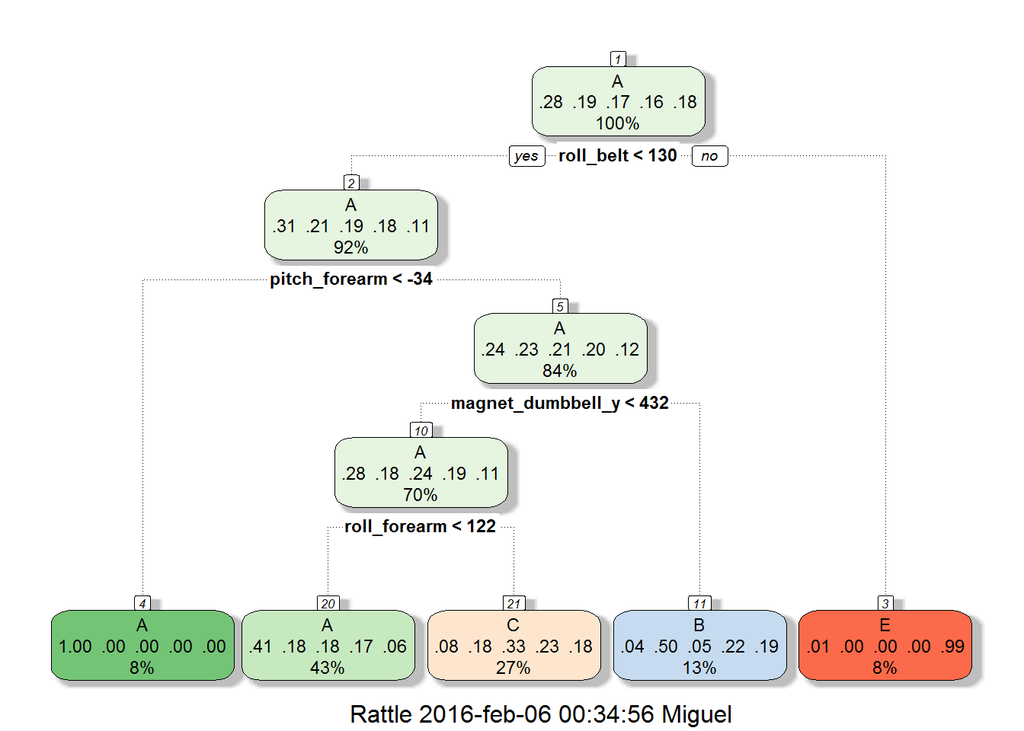

```r
mofFit<-train( train$classe~.,method="rpart",data=train)
fancyRpartPlot(mofFit$finalModel)
```

The problem of applying this algorithm is their low accuracy.

```r
prediccion<-predict(mofFit,newdata=test)
confusionMatrix(prediccion, test$classe)
```

```
## Confusion Matrix and Statistics
##
##           Reference
## Prediction    A    B    C    D    E
##          A 1262  399  424  347  131
##          B   35  337   24  164  121
##          C   95  213  407  293  234
##          D    0    0    0    0    0
##          E    3    0    0    0  415
##
## Overall Statistics
##
##                Accuracy : 0.4937
##                  95% CI : (0.4796, 0.5078)
##     No Information Rate : 0.2845
##     P-Value [Acc > NIR] : < 2.2e-16
##
##                   Kappa : 0.3378
##  Mcnemar's Test P-Value : NA
##
## Statistics by Class:
##
##                      Class: A Class: B Class: C Class: D Class: E
## Sensitivity            0.9047  0.35511  0.47602   0.0000  0.46060
## Specificity            0.6292  0.91302  0.79378   1.0000  0.99925
## Pos Pred Value         0.4924  0.49486  0.32770      NaN  0.99282
## Neg Pred Value         0.9432  0.85508  0.87766   0.8361  0.89166
## Prevalence             0.2845  0.19352  0.17435   0.1639  0.18373
## Detection Rate         0.2573  0.06872  0.08299   0.0000  0.08462
## Detection Prevalence   0.5226  0.13887  0.25326   0.0000  0.08524
## Balanced Accuracy      0.7669  0.63407  0.63490   0.5000  0.72992
```

RANDOM FOREST ALGORITHM AND CROSS VALIDATION

Now the new step is applying Randon Forest to our data. K-fold cross-validation is used during the training with a 3-fold .

mod_rf<- train(classe~ .,data = train,method=“rf”,trControl=trainControl(method=“cv”,number=3))